# Oral Glucose Tolerance Test Regression Analysis

Elombe Calvert

2023-01-04

[1] *Introduction, Variable Selection*

```
                   ***Research Question***
```

Does there exist an association between blood glucose levels from the Oral Glucose Tolerance Test (OGTT) used to diagnose diabetes and Age, BMI, Systolic blood pressure, Diastolic blood pressure, income to poverty ratio, total cholesterol, triglycerides, Apolipoprotein, glycosylated hemoglobin and plasma insulin levels?

```
                   ***Project Motivation***
```

Diabetes Mellitus type 2 is a chronic condition in which the body’s pancreas does not produce enough insulin or does not use insulin effectively due to acquired insulin resistance. This results in high blood sugar levels, which can damage the body’s organs and lead to a range of complications such peripheral neuropathy,diabetic retinopathy, cardiovascular diasese, Nephropathy among others.

Risk factors for diabetes type 2 include being overweight or obese, having high blood pressure, having high levels of lipids (fats) in the blood, being older, having a low income to poverty ratio, having a high BMI (a measure of body fat), and having high levels of glycosylated hemoglobin (a measure of long-term blood sugar control).

The gold standard for diagnosing diabetes is the Oral Glucose Tolerance Test (OGTT). In this test, a person is given a sweet drink containing a specific amount of glucose, and their blood sugar levels are measured at regular intervals over the next two hours.

Thus, in this study, I will use multiple linear regression to investigate the relationship between blood glucose levels from the OGTT test, and a number of potential predictor variables including blood pressure, lipids, age, income to poverty ratio, Apolipoprotein B, BMI, plasma insulin levels, and glycosylated hemoglobin. By carefully analyzing the strength and direction of the association between these variables, we will be able to determine whether they are significant predictors of OGTT blood glucose levels which can be used in the diagnosis of diabetes. Through this analysis, I aim to provide valuable insights that can improve our understanding of the factors that contribute to diabetes.

# Subset of NHANES data set 2013-2014

```r
# Load data file
NHANES.file <- read.csv("nhanes_13_14_subset_updated.csv")
```

# Outcome variable

[1] (LBXGLT) OGTT blood glucose levels

# Predictor variables

[1] (RIDAGEYR) Age [10] (BPXSY2) systolic blood Pressure 2 [2] (INDFMPIR) Income/Poverty Ratio [11] (BPXSY3) systolic blood Pressure 3 [3] (BMXBMI ) Body Mass Index [12] (BPXDI1) diastolic blood Pressure 1 [4] (LBXTR ) Triglycerides [13] (BPXDI2) diastolic blood Pressure 2 [5] (LBXTC ) Total Cholesterol [14] (BPXDI3) diastolic blood Pressure 3 [6] (LBXGH ) Glycosylated hemoglobin [15] (BPXDI4) diastolic blood Pressure 4 [7] (LBXIN ) Plasma Insulin  
[8] (LBXAPB ) Apolipoprotein B  
[9] (BPXSY1 ) systolic blood Pressure 1

```r
# Selected variables as shown above
data.set <- NHANES.file %>% dplyr::select(c(RIDAGEYR,INDFMPIR,BMXBMI,BPXSY1,BPXSY2,BPXSY3,BPXSY4,BPXDI1,BPXDI2,BPXDI3,BPXDI4,LBXTR,LBXTC,LBXGH,LBXIN,LBXAPB,LBXGLT))

colnames(data.set)
```

```
##  [1] "RIDAGEYR" "INDFMPIR" "BMXBMI"   "BPXSY1"   "BPXSY2"   "BPXSY3"
##  [7] "BPXSY4"   "BPXDI1"   "BPXDI2"   "BPXDI3"   "BPXDI4"   "LBXTR"
## [13] "LBXTC"    "LBXGH"    "LBXIN"    "LBXAPB"   "LBXGLT"
```

[2] *Exploratory analysis and QC of the data*

Since OGTT levels is my outcome variable, all patients without this lab value is excluded from the study.

```r
# Drop rows based on missing values in response variable (OGTT)
clean.data <- data.set %>% drop_na(LBXGLT)
```

Due to ‘messy’ state of the data set the median was used to impute missing continuous values for each variable due to its insensitivity to non-normality and outlier values. This method was chosen over dropping NAs from data set.

```r
# Impute missing values using median for predictor variables in data set
clean.data <- clean.data %>% mutate(across(where(is.numeric), ~replace_na(., median(., na.rm=TRUE))))
```

In clinical practice a single blood pressure has limited clinical value, thus the decision was made to average the four systolic blood pressures and the four diastolic blood pressures thus condensing to two variables.

```r
# Merge blood pressures into two variables: Systolic and Diastolic
BPXSY <- data.frame(BPXSY=rowMeans(clean.data[,c(4:7)]))
BPXDI <- data.frame(BPXDI=rowMeans(clean.data[,c(8:11)]))
data  <- cbind(clean.data,BPXSY, BPXDI) %>% dplyr::select(-c(BPXSY1,BPXSY2,BPXSY3,BPXSY4,BPXDI1,BPXDI2,BPXDI3,BPXDI4))
```

All predictor variables were scaled, where as the independent variable was not. This was done to place each variable on the same scale, mean while leaving the outcome variable unscaled so that the actual fitted values of the model can be interpreted.

```r
# Scale independent variables within data set
data <- scale(data[,c(1:8,10,11)],center = F, scale =T)%>% cbind(.,clean.data$LBXGLT) %>% data.frame(.) %>%
mutate(LBXGLT = V11) %>% dplyr::select(-V11)
```

The collinearity matrix between the variables below showed only reasonably correlated variables:

- Total Cholesterol and Apolipoprotein B = 0.86
- Glycosylated Hemoglobin and OGTT levels = 0.62

```r
# Checking collinearity between predictors

# correlation Matrix
cor_var <- data.frame(cor(data))
head(cor_var)
```

```
##           RIDAGEYR    INDFMPIR      BMXBMI       LBXTR     LBXTC       LBXGH
## RIDAGEYR 1.0000000  0.15635864  0.14583319  0.12787416 0.3317242  0.34366256
## INDFMPIR 0.1563586  1.00000000 -0.07830219 -0.01238438 0.1186177 -0.02116342
## BMXBMI   0.1458332 -0.07830219  1.00000000  0.18780015 0.1163161  0.22188937
## LBXTR    0.1278742 -0.01238438  0.18780015  1.00000000 0.3633208  0.16581961
## LBXTC    0.3317242  0.11861767  0.11631607  0.36332083 1.0000000  0.20166563
## LBXGH    0.3436626 -0.02116342  0.22188937  0.16581961 0.2016656  1.00000000
##                 LBXIN     LBXAPB       BPXSY      BPXDI      LBXGLT
## RIDAGEYR -0.092233393 0.30968409  0.46134056 0.16900710  0.32172372
## INDFMPIR -0.117381517 0.05590375 -0.00258248 0.03984434 -0.02527402
## BMXBMI    0.529772997 0.24152688  0.23198810 0.19755723  0.19543242
## LBXTR     0.231876547 0.43203263  0.18249460 0.19002175  0.21297287
## LBXTC     0.006084283 0.86600155  0.22393798 0.21635213  0.16732918
## LBXGH     0.155013336 0.23700181  0.26560311 0.07941595  0.62128204
```

Scatter plot showing relationships between all variables in data set.

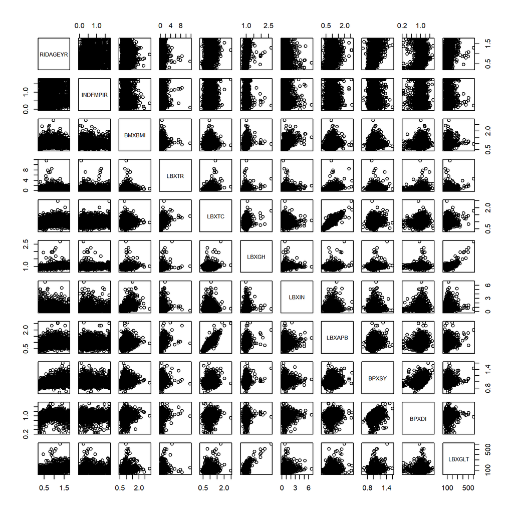

```r
# Scatter plots of all variables to examine relationships
plot(data)
```

Interesting Plots with potential collinearity based on Correlation matrix and scatter plots.

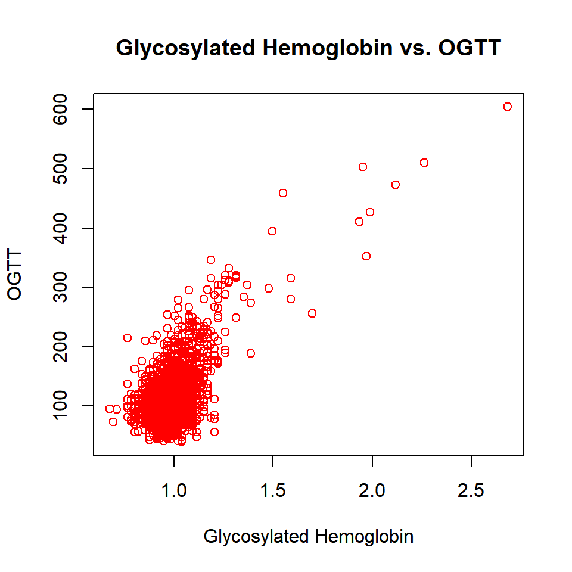

```r
# Glycosylated Hemoglobin vs. OGTT
plot(data$LBXGH,data$LBXGLT,main = "Glycosylated Hemoglobin vs. OGTT",
xlab = "Glycosylated Hemoglobin", ylab = "OGTT", col="red")
```

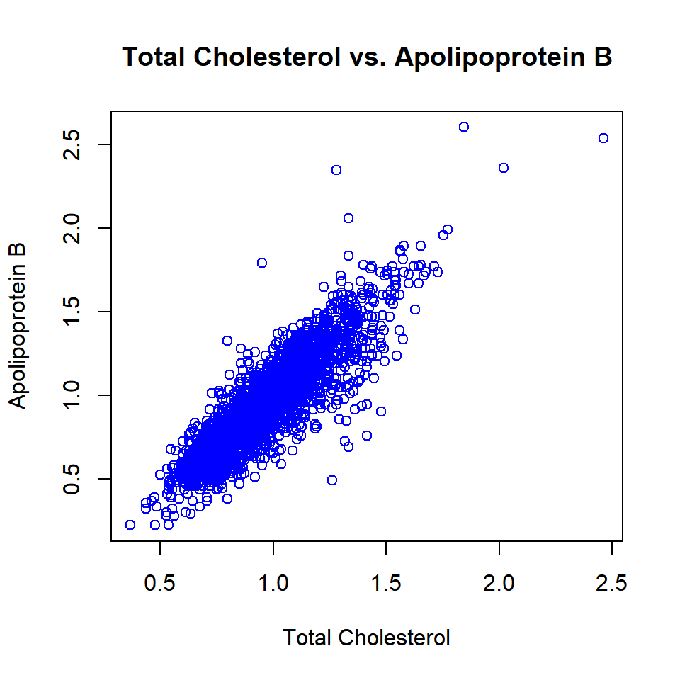

```r
# Total Cholesterol vs. Apolipoprotein B
plot(data$LBXTC,data$LBXAPB,main = "Total Cholesterol vs. Apolipoprotein B",
xlab = "Total Cholesterol", ylab = "Apolipoprotein B", col="blue")
```

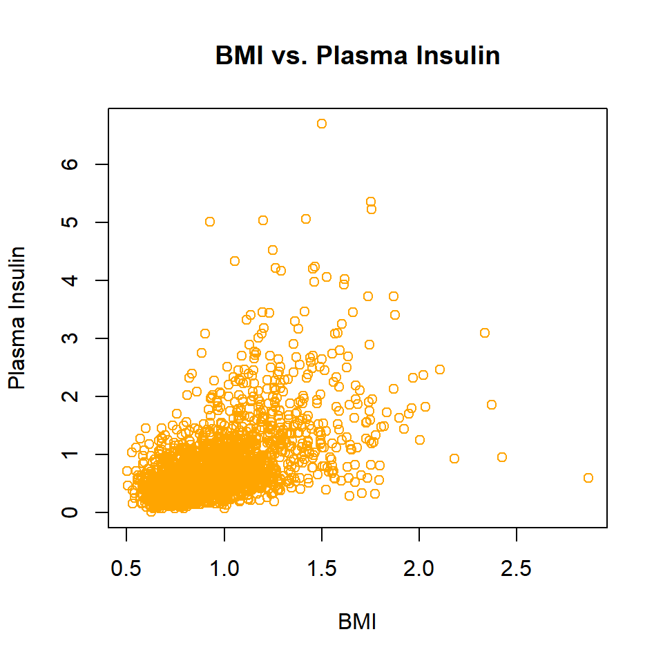

```r
# BMI vs. Plasma Insulin
plot(data$BMXBMI,data$LBXIN,main = "BMI vs. Plasma Insulin",
xlab = "BMI", ylab = "Plasma Insulin", col="orange")
```

[2] *Choose a regression model*

Multiple linear regression is a powerful statistical tool that allows us to examine the relationship between a target variable and multiple predictor variables. Thus the goal of the Multiple linear regression models built, will assess the association between the predictors and the outcome variable outlined above.

# The full multiple regression model

This model type was chosen was it will allow fo the relationship between multiple predictor variables and a continuous outcome to be assessed. The full model contains all the predictor variables modelling the outcome, OGTT levels.

```r
# Model Definition
full_model <- lm(LBXGLT~., data=data)

# Model summary
summary(full_model)
```

```
##
## Call:
## lm(formula = LBXGLT ~ ., data = data)
##
## Residuals:
##      Min       1Q   Median       3Q      Max
## -128.433  -23.147   -3.002   18.032  202.421
##
## Coefficients:
##             Estimate Std. Error t value Pr(>|t|)
## (Intercept) -161.972     10.644 -15.217  < 2e-16 ***
## RIDAGEYR      13.466      2.124   6.339 2.77e-10 ***
## INDFMPIR      -1.365      1.363  -1.002  0.31645
## BMXBMI        -7.995      3.639  -2.197  0.02812 *
## LBXTR          5.756      1.321   4.358 1.37e-05 ***
## LBXTC        -10.046      7.091  -1.417  0.15672
## LBXGH        241.441      7.739  31.196  < 2e-16 ***
## LBXIN          9.693      1.452   6.677 3.05e-11 ***
## LBXAPB         5.646      5.590   1.010  0.31264
## BPXSY         30.051      8.913   3.372  0.00076 ***
## BPXDI         -3.507      5.586  -0.628  0.53014
## ---
## Signif. codes:  0 '***' 0.001 '**' 0.01 '*' 0.05 '.' 0.1 ' ' 1
##
## Residual standard error: 35.8 on 2334 degrees of freedom
## Multiple R-squared:  0.4277, Adjusted R-squared:  0.4253
## F-statistic: 174.4 on 10 and 2334 DF,  p-value: < 2.2e-16
```

# Evalaute regression assumptions

[A] Multicollinearity

- VIF is less than 1 : No correlation
- VIF is between 1-5 : Moderate correlation
- VIF is above 5 : Severe correlation

Variance inflation factor (VIF) is used for detecting the multicollinearity

From the VIF barplot, only two predictors showed significant multicollinearity, Apolipoprotein and Total cholesterol, which is consistent with findings from our correlation matrix. Since the literature has little evidence to support Apolipoprotein as a good predictor/ risk factor for diabetes, it will be dropped from the model.

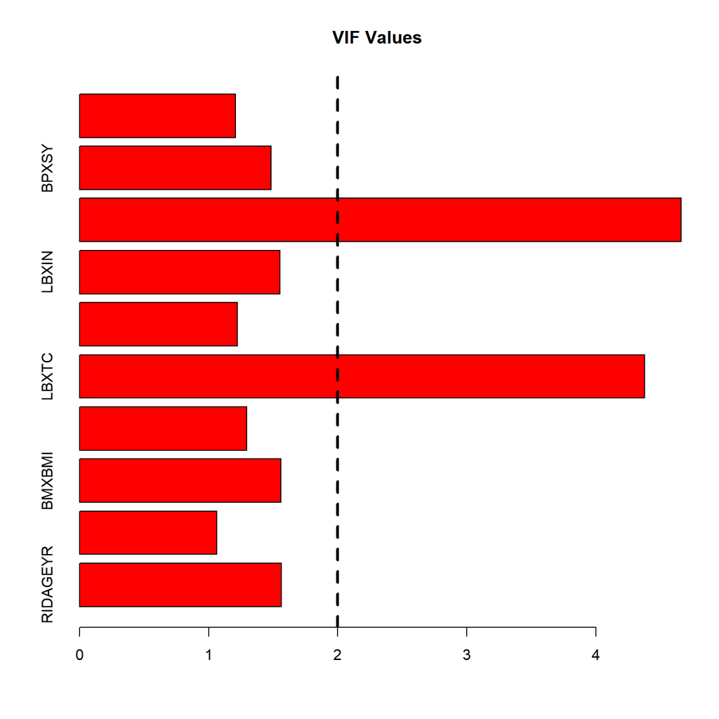

```r
# create vector of VIF values
vif_values <- vif(full_model)

# bar cart to display each VIF value
barplot(vif_values, main = "VIF Values", horiz = T, col = "red")

# Threshold of 2
abline(v = 2, lwd = 3, lty = 2)
```

[B] Normality

From the barplot of the residual values from the model, it can be seen that the residuals are approximately normally distributed with a slight right skew.

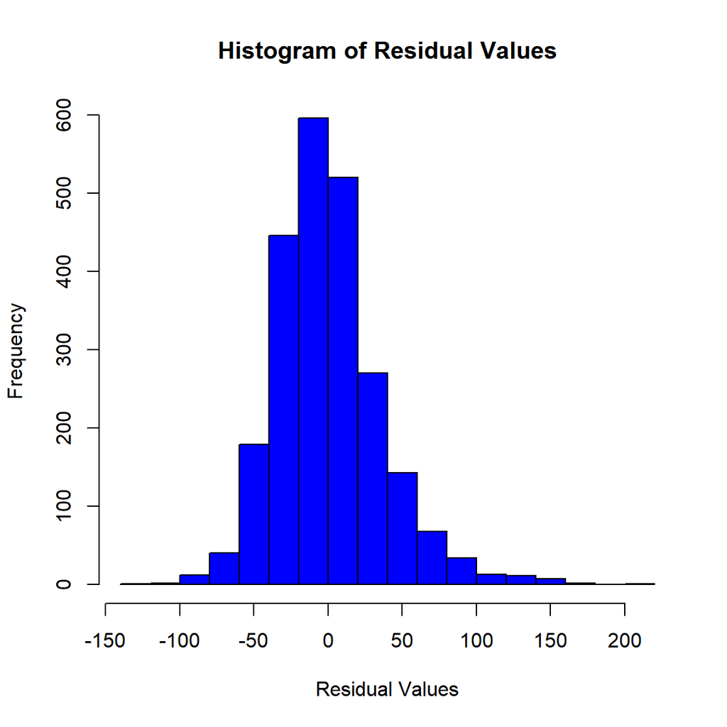

```r
# Extracting fitted values
fit_mod = fitted(full_model)

# Extracting residuals
res_mod = resid(full_model)

# histogram of residual values
hist(res_mod,main = "Histogram of Residual Values", xlab = "Residual Values", col = "blue")
```

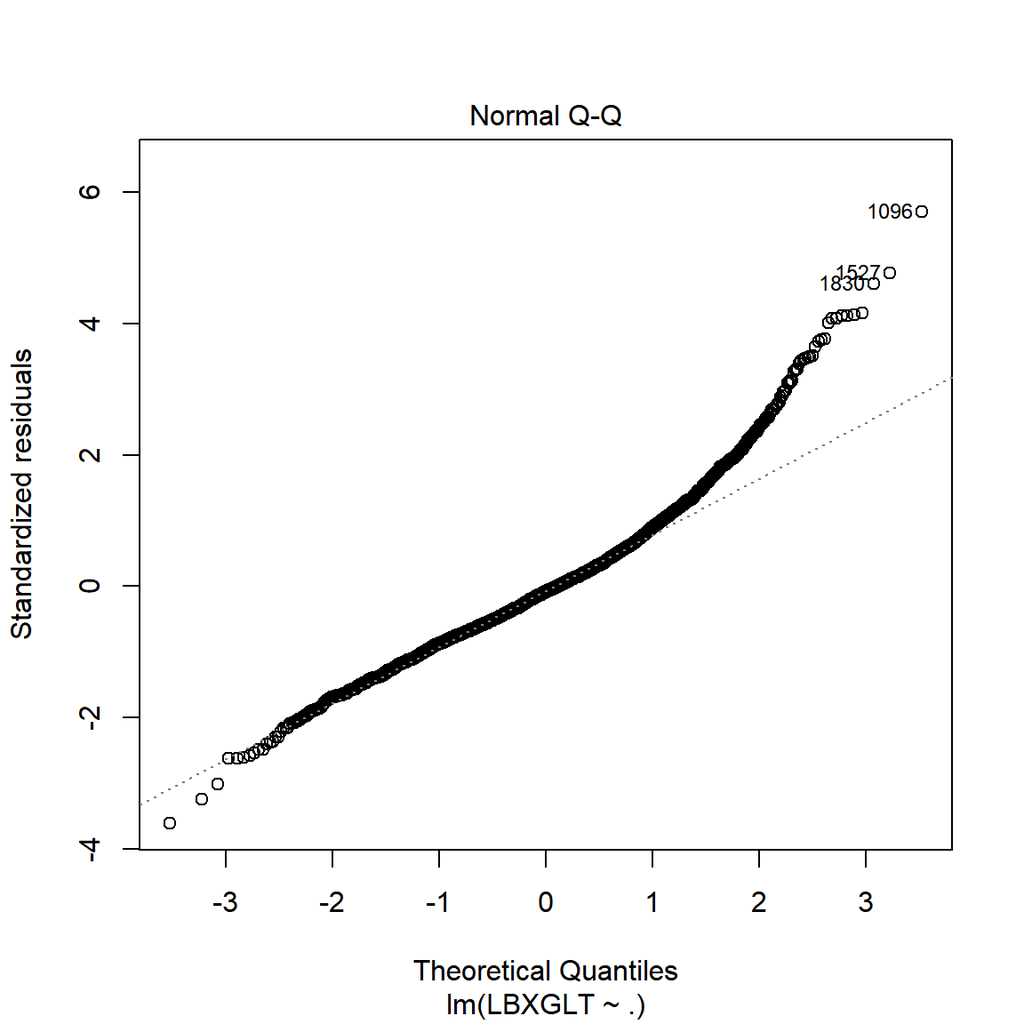

```r
# Q-Q plot of residuals
plot(full_model,2)
```

[C] Linearity

This assumption is checked by looking if there exists any pattern seen in the fitted values which is indicated by the shape of the red line in the plot below. It can be seen that the red line is not horizontal but has non-linear shape, thus indicating a non-linear relationship between the outcome variable and the predictors.

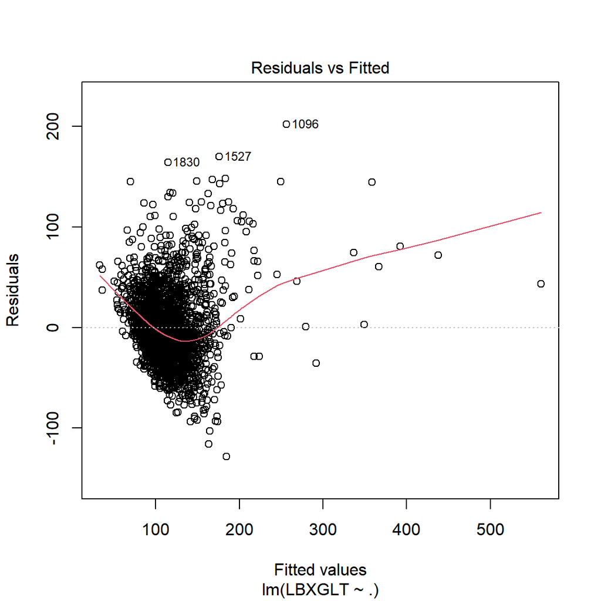

```r
# Plot fitted values vs Residuals
plot(full_model,1)
```

[D] Homoscedasticity

From the Scale-Location plot below, the residuals display Heteroscedasticity which is non-constant variance in the residuals with differing fitted values.

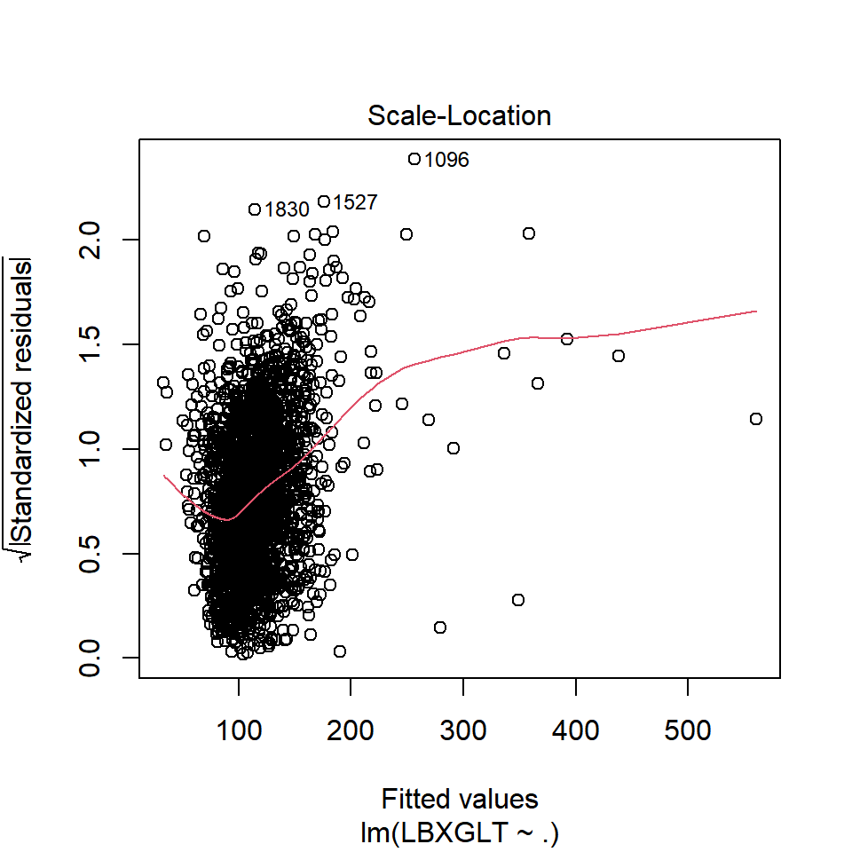

```r
# Scale-Location plot

plot(full_model,3)
```

[3] *Conduct variable selection*

The base model which only includes the intercept and the full model which has all predictor variables excluding `Apolipoprotein B` is defined. This will reduce the model complexity and allow for more interpretable coefficients.

```r
# Model Definition
base_model <- lm(LBXGLT~ 1,data=data)
full_model <- lm(LBXGLT~., data=data[,c(1:7,9:11)])
```

In order perform feature selection to construct the most robust model, iterative feature selection is used via stepAIC, backward selection. Thus, starting with a full model containing all the predictors was done, then insignificant predictors are iteratively removed leaving only variables that explain much of the variance in the target variable. This was ideal in this study where the aim is to assess the relationship between predictors and the outcome variable by finding only the features with a significant relationship with the outcome of interest.

The features selection through this process as being of importance are: Age (RIDAGEYR), BMI (BMXBMI), Triglycerides (LBXTR), Glycosylated hemoglobin (LBXGH), Plasma insulin levels (LBXIN) and Systolic blood pressure(BPXSY) which are all significantly associated with the outcome, OGTT levels.

```r
# Iterative phase
stepAIC(full_model,scope =list(lower=base_model,upper=full_model), data=data, direction = "backward")
```

```
## Start:  AIC=16789.97
## LBXGLT ~ RIDAGEYR + INDFMPIR + BMXBMI + LBXTR + LBXTC + LBXGH +
##     LBXIN + BPXSY + BPXDI
##
##            Df Sum of Sq     RSS   AIC
## - BPXDI     1       458 2992344 16788
## - LBXTC     1      1395 2993281 16789
## - INDFMPIR  1      1452 2993337 16789
## <none>                  2991885 16790
## - BMXBMI    1      5493 2997378 16792
## - BPXSY     1     14361 3006247 16799
## - LBXTR     1     27502 3019387 16809
## - RIDAGEYR  1     52173 3044059 16829
## - LBXIN     1     59667 3051552 16834
## - LBXGH     1   1253045 4244930 17608
##
## Step:  AIC=16788.33
## LBXGLT ~ RIDAGEYR + INDFMPIR + BMXBMI + LBXTR + LBXTC + LBXGH +
##     LBXIN + BPXSY
##
##            Df Sum of Sq     RSS   AIC
## - INDFMPIR  1      1523 2993867 16788
## - LBXTC     1      1599 2993943 16788
## <none>                  2992344 16788
## - BMXBMI    1      5971 2998315 16791
## - BPXSY     1     14100 3006444 16797
## - LBXTR     1     27095 3019438 16808
## - RIDAGEYR  1     52597 3044941 16827
## - LBXIN     1     60149 3052493 16833
## - LBXGH     1   1259038 4251382 17610
##
## Step:  AIC=16787.52
## LBXGLT ~ RIDAGEYR + BMXBMI + LBXTR + LBXTC + LBXGH + LBXIN +
##     BPXSY
##
##            Df Sum of Sq     RSS   AIC
## - LBXTC     1      1920 2995787 16787
## <none>                  2993867 16788
## - BMXBMI    1      5700 2999567 16790
## - BPXSY     1     14736 3008603 16797
## - LBXTR     1     27457 3021324 16807
## - RIDAGEYR  1     51094 3044961 16825
## - LBXIN     1     60984 3054851 16833
## - LBXGH     1   1268281 4262148 17614
##
## Step:  AIC=16787.03
## LBXGLT ~ RIDAGEYR + BMXBMI + LBXTR + LBXGH + LBXIN + BPXSY
##
##            Df Sum of Sq     RSS   AIC
## <none>                  2995787 16787
## - BMXBMI    1      5973 3001761 16790
## - BPXSY     1     14359 3010146 16796
## - LBXTR     1     25685 3021472 16805
## - RIDAGEYR  1     49207 3044994 16823
## - LBXIN     1     63037 3058824 16834
## - LBXGH     1   1266968 4262755 17612
```

```
##
## Call:
## lm(formula = LBXGLT ~ RIDAGEYR + BMXBMI + LBXTR + LBXGH + LBXIN +
##     BPXSY, data = data[, c(1:7, 9:11)])
##
## Coefficients:
## (Intercept)     RIDAGEYR       BMXBMI        LBXTR        LBXGH        LBXIN
##    -169.531       12.682       -7.699        5.451      241.943       10.080
##       BPXSY
##      28.466
```

[4] *Evaluate model fit*

The final model contains only 6 out of 10 predictor variables, all of which are statistically significant.

```r
# Final Model
final_model <- lm(formula = LBXGLT ~ RIDAGEYR + BMXBMI + LBXTR + LBXGH + LBXIN + BPXSY, data = data)
summary(final_model)
```

```
##
## Call:
## lm(formula = LBXGLT ~ RIDAGEYR + BMXBMI + LBXTR + LBXGH + LBXIN +
##     BPXSY, data = data)
##
## Residuals:
##      Min       1Q   Median       3Q      Max
## -126.492  -23.116   -3.046   18.252  202.281
##
## Coefficients:
##             Estimate Std. Error t value Pr(>|t|)
## (Intercept) -169.531      9.856 -17.201  < 2e-16 ***
## RIDAGEYR      12.682      2.046   6.197 6.78e-10 ***
## BMXBMI        -7.699      3.566  -2.159 0.030941 *
## LBXTR          5.451      1.217   4.477 7.93e-06 ***
## LBXGH        241.943      7.694  31.445  < 2e-16 ***
## LBXIN         10.080      1.437   7.014 3.02e-12 ***
## BPXSY         28.466      8.503   3.348 0.000828 ***
## ---
## Signif. codes:  0 '***' 0.001 '**' 0.01 '*' 0.05 '.' 0.1 ' ' 1
##
## Residual standard error: 35.8 on 2338 degrees of freedom
## Multiple R-squared:  0.4267, Adjusted R-squared:  0.4252
## F-statistic:   290 on 6 and 2338 DF,  p-value: < 2.2e-16
```

Plotting the final model’s residual values

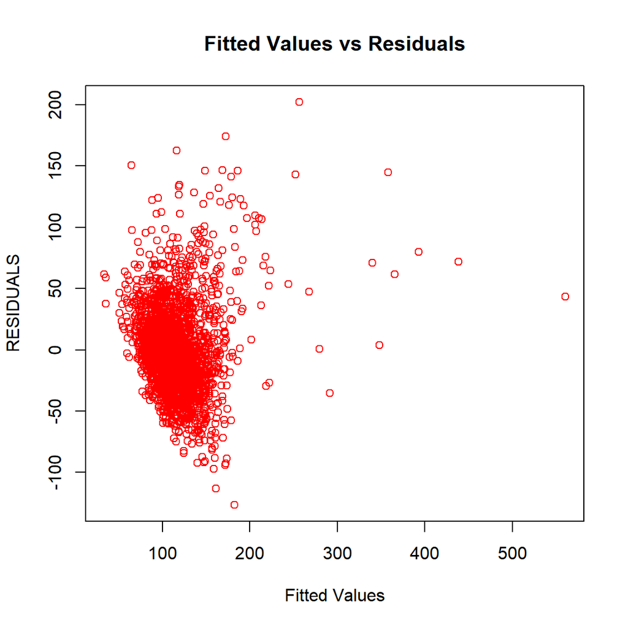

```r
# Extracting fitted values Height
fit_model = fitted(final_model)

# Extracting residual values Height
res_model = resid(final_model)

# Plot fitted values vs Residuals
plot(fit_model,res_model, main = "Fitted Values vs Residuals", xlab = "Fitted Values", ylab = "RESIDUALS", col="red")
```

In assessing how well the model fits to the data, the coefficient of determination, also known as R-squared will be evaluated. In the final model, the R-squared was 0.426. Thus the predictor variables in the final model,RIDAGEYR, BMXBMI, LBXTR, LBXGH, LBXIN and BPXSY was able to explain ~43% of the variance that exists in the outcome variable LBXGLT.

```r
# R-squared value of final model
summary(final_model)$r.squared
```

```
## [1] 0.4267106
```

[5] *Alternative Model*

Of the 6 predictor variable in the final model, only two variables directly relates to blood glucose levels physiologically in the human body. Thus a model will be constructed and evaluated based solely on these two predictor variables which are:

- Serum Plasma Insulin
- Glycosylated Hemoglobin

```r
# Alternative Model
Alt_model <- lm(LBXGLT~LBXIN+LBXGH, data =data)
summary(Alt_model)
```

```
##
## Call:
## lm(formula = LBXGLT ~ LBXIN + LBXGH, data = data)
##
## Residuals:
##      Min       1Q   Median       3Q      Max
## -113.958  -23.711   -4.575   17.635  189.001
##
## Coefficients:
##             Estimate Std. Error t value Pr(>|t|)
## (Intercept) -159.650      7.164  -22.29  < 2e-16 ***
## LBXIN          8.717      1.206    7.23 6.51e-13 ***
## LBXGH        269.760      7.250   37.21  < 2e-16 ***
## ---
## Signif. codes:  0 '***' 0.001 '**' 0.01 '*' 0.05 '.' 0.1 ' ' 1
##
## Residual standard error: 36.61 on 2342 degrees of freedom
## Multiple R-squared:  0.3994, Adjusted R-squared:  0.3989
## F-statistic: 778.7 on 2 and 2342 DF,  p-value: < 2.2e-16
```

The metric that will be used to compare both the final model and the alternative model is the Akaike information criterion (AIC), where lower AIC value indicates a better-fitting model.

```r
ALT_AIC <- AIC(Alt_model)
FIN_AIC <- AIC(final_model)

paste("The AIC of the alternative model is",round(ALT_AIC,1), "whereas the AIC of the final model is",round(FIN_AIC,1),". Thus, it can be seen that the final model has a lower AIC which means that it is better able to explain the data than the alternative model. The final model is the better model."  )
```

```
## [1] "The AIC of the alternative model is 23545 whereas the AIC of the final model is 23443.8 . Thus, it can be seen that the final model has a lower AIC which means that it is better able to explain the data than the alternative model. The final model is the better model."
```

[6] *Follow-up Analysis*

Hypothesis testing for coefficient(s)

H0 : All of the coefficients in the regression model are equal to zero H1 : At least one of the coefficients is significantly different from zero

```r
# Evaluate F-statistic and p value of F statistic

y  <- summary(final_model)
FS <- y$fstatistic[1]
PV <- pf(y$fstatistic[1],y$fstatistic[2],y$fstatistic[3],lower.tail=FALSE)

paste("Having an F-statistic of",round(FS,0),"with a signficant p-value of",PV,", we can reject the H0 and accept H1 that atleast one coefficient is significantly different from zero. In essence, atleast one of our predictor variable in our final model has a significant association with our outcome of interest.")
```

[output not shown]

#CONCLUSION:

Multiple linear regression as a statistic method was used to determine significant associations between predictor variables Age, BMI, Triglycerides, Glycosylated Hemoglobin, Plasma insulin levels, Systolic blood pressure and our outcome variable OGTT blood glucose levels.

```
                              ***THE END***
```